# forcats::fct_shift

Function of the Week

Shift factor levels to left or right, wrapping around at end

Author

Danielle Higbee

Published

February 28, 2024

# 1 `forcats::fct_shift`

In this document, I will introduce the ’fct_shift` function and show what it’s for.

```r
#load tidyverse up
library(tidyverse)
pacman::p_load(
  tidyverse,    # data management + ggplot2 graphics
  readxl,       # import excel data
  here,         # helps with file management
  janitor,       # for data cleaning, making tables
  skimr,
  titanic       # needed to use the titanic dataset
  )

#install 'forcats'
#install.packages("forcats")
library(forcats) #load forcats package
library(datasets) #load built in datasets to r

#example dataset
data("Orange")
data("titanic_train")
```

## 1.1 What is it for?

> Discuss what the function does. Learn from the examples, but show how to use it using another dataset such as `penguins`. If you can provide two examples, even better!

Shift factor levels left or right, wrapping around at the end.

### 1.1.1 Arguments

This function is from the ‘forcats’ package and is used to shift levels in a factor. The following is the syntax:

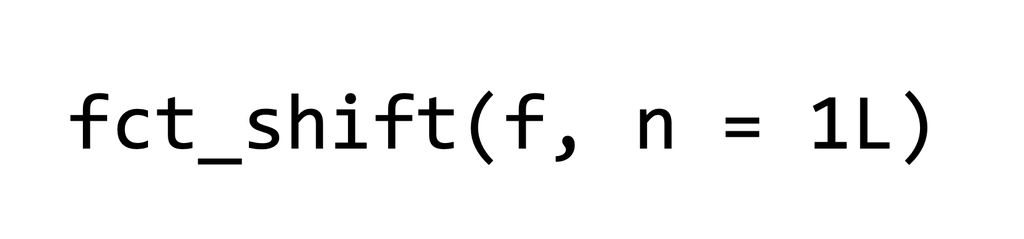

Syntax

$\text{f = A factor}$

$\text{n = positive values shift to the left; negative values shift to the right}$

#### 1.1.1.1 Example Shift to Left

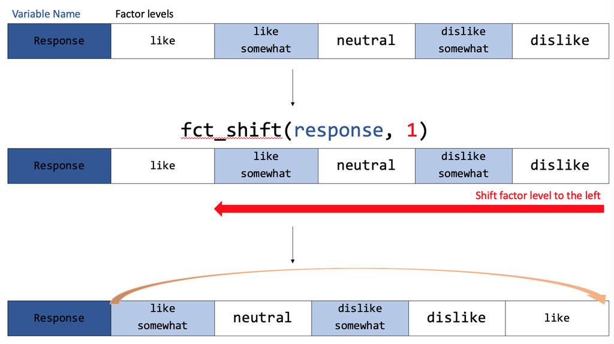

Shift Left

#### 1.1.1.2 Example Shift to Right

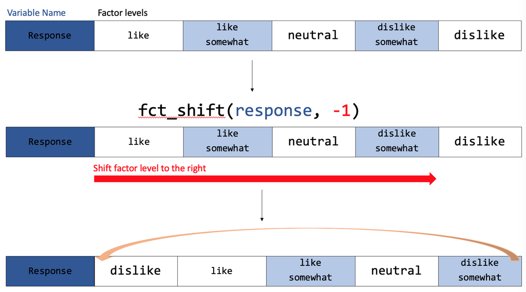

Shift Right

### 1.1.2 Example given

```r
x <- factor(
  c("Mon", "Tue", "Wed"),
  levels = c("Sun", "Mon", "Tue", "Wed", "Thu", "Fri", "Sat"),
  ordered = TRUE
)
x
```

```
[1] Mon Tue Wed
Levels: Sun < Mon < Tue < Wed < Thu < Fri < Sat
```

```r
fct_shift(x) #default to shift left 1
```

```
[1] Mon Tue Wed
Levels: Mon < Tue < Wed < Thu < Fri < Sat < Sun
```

```r
fct_shift(x, 2)
```

```
[1] Mon Tue Wed
Levels: Tue < Wed < Thu < Fri < Sat < Sun < Mon
```

```r
fct_shift(x, -1)
```

```
[1] Mon Tue Wed
Levels: Sat < Sun < Mon < Tue < Wed < Thu < Fri
```

### 1.1.3 Example with ‘Orange’ dataset

```r
glimpse(Orange)
```

```
Rows: 35
Columns: 3
$ Tree          <ord> 1, 1, 1, 1, 1, 1, 1, 2, 2, 2, 2, 2, 2, 2, 3, 3, 3, 3, 3,…
$ age           <dbl> 118, 484, 664, 1004, 1231, 1372, 1582, 118, 484, 664, 10…
$ circumference <dbl> 30, 58, 87, 115, 120, 142, 145, 33, 69, 111, 156, 172, 2…
```

```r
factor(Orange$Tree)
```

```
 [1] 1 1 1 1 1 1 1 2 2 2 2 2 2 2 3 3 3 3 3 3 3 4 4 4 4 4 4 4 5 5 5 5 5 5 5
Levels: 3 < 1 < 5 < 2 < 4
```

```r
Orange$Tree <- factor(Orange$Tree,
    levels = c("1", "2", "3", "4", "5"))

levels(Orange$Tree)
```

```
[1] "1" "2" "3" "4" "5"
```

```r
tabyl(Orange$Tree)
```

```
 Orange$Tree n percent
           1 7     0.2
           2 7     0.2
           3 7     0.2
           4 7     0.2
           5 7     0.2
```

```r
fct_shift(Orange$Tree) # default to shift 1 left
```

```
 [1] 1 1 1 1 1 1 1 2 2 2 2 2 2 2 3 3 3 3 3 3 3 4 4 4 4 4 4 4 5 5 5 5 5 5 5
Levels: 2 < 3 < 4 < 5 < 1
```

```r
fct_shift(Orange$Tree, 1) # shift left
```

```
 [1] 1 1 1 1 1 1 1 2 2 2 2 2 2 2 3 3 3 3 3 3 3 4 4 4 4 4 4 4 5 5 5 5 5 5 5
Levels: 2 < 3 < 4 < 5 < 1
```

```r
fct_shift(Orange$Tree, -1) # shift right
```

```
 [1] 1 1 1 1 1 1 1 2 2 2 2 2 2 2 3 3 3 3 3 3 3 4 4 4 4 4 4 4 5 5 5 5 5 5 5
Levels: 5 < 1 < 2 < 3 < 4
```

```r
fct_shift(Orange$Tree, 4)
```

```
 [1] 1 1 1 1 1 1 1 2 2 2 2 2 2 2 3 3 3 3 3 3 3 4 4 4 4 4 4 4 5 5 5 5 5 5 5
Levels: 5 < 1 < 2 < 3 < 4
```

### 1.1.4 Example with ‘Titanic’ dataset

```r
glimpse(titanic_train)
```

```
Rows: 891
Columns: 12
$ PassengerId <int> 1, 2, 3, 4, 5, 6, 7, 8, 9, 10, 11, 12, 13, 14, 15, 16, 17,…
$ Survived    <int> 0, 1, 1, 1, 0, 0, 0, 0, 1, 1, 1, 1, 0, 0, 0, 1, 0, 1, 0, 1…
$ Pclass      <int> 3, 1, 3, 1, 3, 3, 1, 3, 3, 2, 3, 1, 3, 3, 3, 2, 3, 2, 3, 3…
$ Name        <chr> "Braund, Mr. Owen Harris", "Cumings, Mrs. John Bradley (Fl…
$ Sex         <chr> "male", "female", "female", "female", "male", "male", "mal…
$ Age         <dbl> 22, 38, 26, 35, 35, NA, 54, 2, 27, 14, 4, 58, 20, 39, 14, …
$ SibSp       <int> 1, 1, 0, 1, 0, 0, 0, 3, 0, 1, 1, 0, 0, 1, 0, 0, 4, 0, 1, 0…
$ Parch       <int> 0, 0, 0, 0, 0, 0, 0, 1, 2, 0, 1, 0, 0, 5, 0, 0, 1, 0, 0, 0…
$ Ticket      <chr> "A/5 21171", "PC 17599", "STON/O2. 3101282", "113803", "37…
$ Fare        <dbl> 7.2500, 71.2833, 7.9250, 53.1000, 8.0500, 8.4583, 51.8625,…
$ Cabin       <chr> "", "C85", "", "C123", "", "", "E46", "", "", "", "G6", "C…
$ Embarked    <chr> "S", "C", "S", "S", "S", "Q", "S", "S", "S", "C", "S", "S"…
```

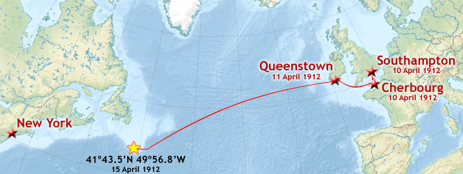

Titantic Voyage Map

```r
factor(titanic_train$Embarked)
```

[output not shown]

```r
titanic_train$Embarked <- factor(titanic_train$Embarked,
  levels = c("C", "Q", "S")
)

levels(titanic_train$Embarked)
```

```
[1] "C" "Q" "S"
```

Levels are in alphabetical order.

We want the ‘Embarked’ column to be in order of the actual voyage of the Titanic. Southampton > Cherbourg > Queenstown

```r
fct_shift(titanic_train$Embarked, -1)
```

```
  [1] S    C    S    S    S    Q    S    S    S    C    S    S    S    S    S
 [16] S    Q    S    S    C    S    S    Q    S    S    S    C    S    Q    S
 [31] C    C    Q    S    C    S    C    S    S    C    S    S    C    C    Q
 [46] S    Q    Q    C    S    S    S    C    S    C    S    S    C    S    S
 [61] C    <NA> S    S    C    C    S    S    S    S    S    S    S    C    S
 [76] S    S    S    S    S    S    S    Q    S    S    S    S    S    S    S
 [91] S    S    S    S    S    S    C    C    S    S    S    S    S    S    S
[106] S    S    S    S    Q    S    C    S    S    C    S    Q    S    C    S
[121] S    S    C    S    S    C    Q    S    C    S    C    S    S    S    S
[136] C    S    S    S    C    C    S    S    Q    S    S    S    S    S    S
[151] S    S    S    S    S    C    Q    S    S    S    S    S    S    S    S
[166] S    S    S    S    S    S    Q    S    S    C    S    S    C    S    S
[181] S    C    S    S    S    S    Q    S    Q    S    S    S    S    S    C
[196] C    Q    S    Q    S    S    S    S    C    S    S    S    C    Q    C
[211] S    S    S    S    Q    C    S    S    C    S    S    S    S    S    S
```

[output cut: 46 more lines]

```r
titanic_train %>%
  mutate(Embarked = fct_shift(Embarked, -1)) %>%
  tabyl(Embarked)
```

```
 Embarked   n     percent valid_percent
        S 644 0.722783389    0.72440945
        C 168 0.188552189    0.18897638
        Q  77 0.086419753    0.08661417
     <NA>   2 0.002244669            NA
```

## 1.2 Is it helpful?

> Discuss whether you think this function is useful for you and your work. Is it the best thing since sliced bread, or is it not really relevant to your work?

This function is helpful! Instead of having to rewrite the entire order of the levels of a factor, you can easily use ‘fct_shift’ to reorder. However, it should be noted that this is useful when ordered factors are cyclical. So cannot work if you are pulling out a singular factor level to place somewhere else.

Citation for titanic dataset: https://cran.r-project.org/web/packages/explore/vignettes/explore_titanic.html

Citation for titantic voyage picture: https://en.m.wikipedia.org/wiki/File:Titanic_voyage_map.png